# `vcd::spine`

spine Spine Plots and Spinograms

#### Desription

Spine plots are a special cases of mosaic plots, and can be seen as a generalization of stacked (or highlighted) bar plots. Analogously, spinograms are an extension of histograms.

#### Usage

```
  spine(x, ...)
## Default S3 method:
spine(xNULL,
      breaks = NULL, ylab_tol = 0.05, off = NULL,
      main = "", xlab = NULL, ylab = NULL, ylim = c(0, 1), margins = c(5.1, 4.1, 4.1, 3.1),
      gp = gpar(), name = "spineplot", newpage = TRUE, pop = TRUE,
      ...)
## S3 method for class 'formula'
spine(formula, data = list(),
      breaks = NULL, ylab_tol = 0.05, off = NULL,
      main = "", xlab = NULL, ylab = NULL, ylim = c(0, 1), margins = c(5.1, 4.1, 4.1, 3.1),
      gp = gpar(), name = "spineplot", newpage = TRUE, pop = TRUE,
      ...)
```

#### Arguments

- `x`: an object, the default method expects either a single variable (interpreted to be the explanatory variable) or a 2-way table. See details.
- `y` a "factor" interpreted to be the dependent variable
- `formula`: a "formula" of typx with a single dependent "factor" and a single explanatory variable.
- `data`: an optional data frame.
- `breaks`: if the explanatory variable is numeric, this controls how it is discretized. breaks is passed to hist and can be a list of arguments.
- `ylab_tol`: convenience tolerance parameter for y-axis annotation. If the distance between two labels drops under this threshold, they are plotted equidistantly.
- `off`: vertical offset between the bars (in per cent). It is fixed to 0 for spinograms and defaults to 2 for spine plots.
- `main`, `xlab`, `ylab` : character strings for annotation
- `ylim`: limits for the y axis
- `margins`: margins when calling plotViewport
- `gp`: a "gpar" object controlling the grid graphical parameters of the rectangles. It should specify in particular a vector of fill colors of the same length as
- `levels(y)`:. The default is to call `gray.colors`.
- `name`: name of the plotting viewport.
- `newpage`: logical. Should grid.newpage be called before plotting?
- `pop`: logical. Should the viewport created be popped?
- `...`: additional arguments passed to plotViewport.

#### Examples

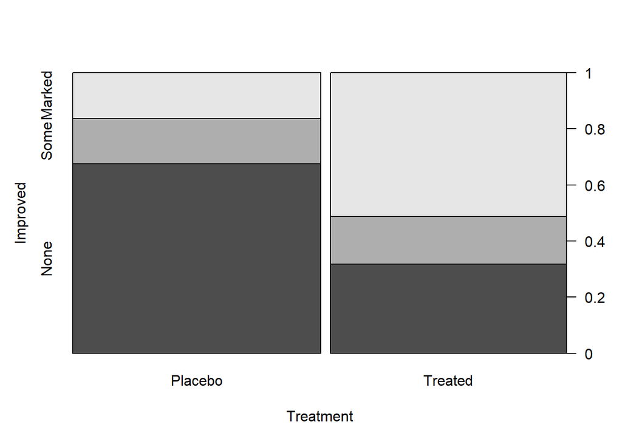

```
##          Improved
## Treatment None Some Marked
##   Placebo   29    7      7
##   Treated   13    7     21
```

```r
## Arthritis data (dependence on a categorical variable)
data("Arthritis")
(spine(Improved ~ Treatment, data = Arthritis))
```

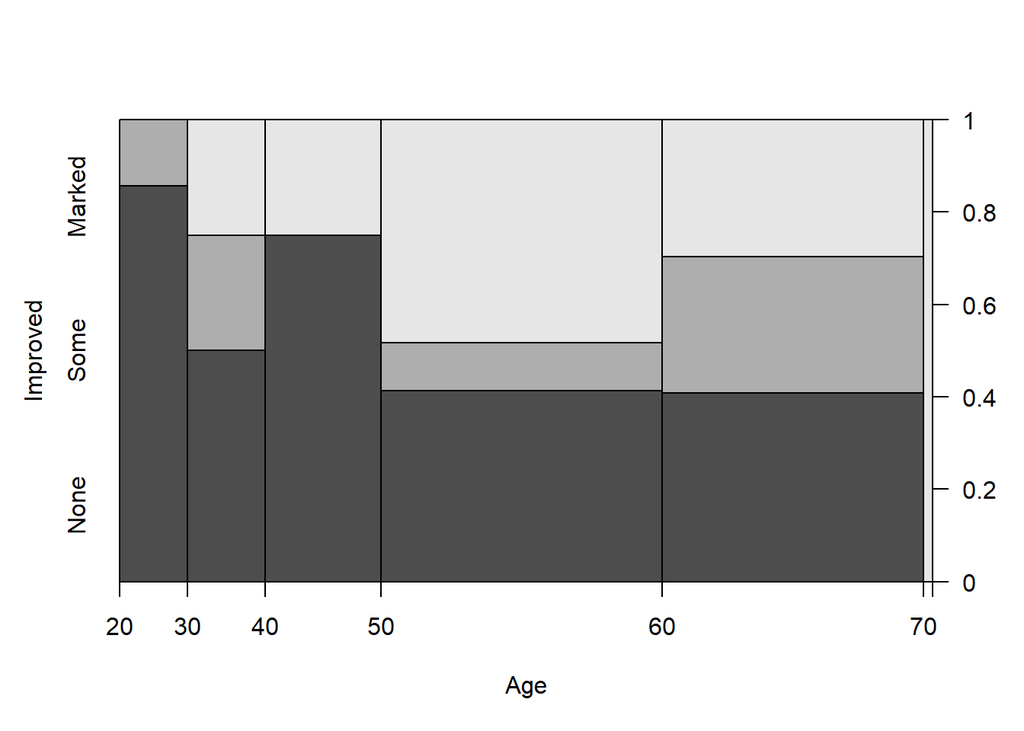

```
##          Improved
## Age       None Some Marked
##   [20,30]    6    1      0
##   (30,40]    4    2      2
##   (40,50]    9    0      3
##   (50,60]   12    3     14
##   (60,70]   11    8      8
##   (70,80]    0    0      1
```

```r
## Arthritis data (dependence on a numerical variable)
(spine(Improved ~ Age, data = Arthritis, breaks = 5))
```

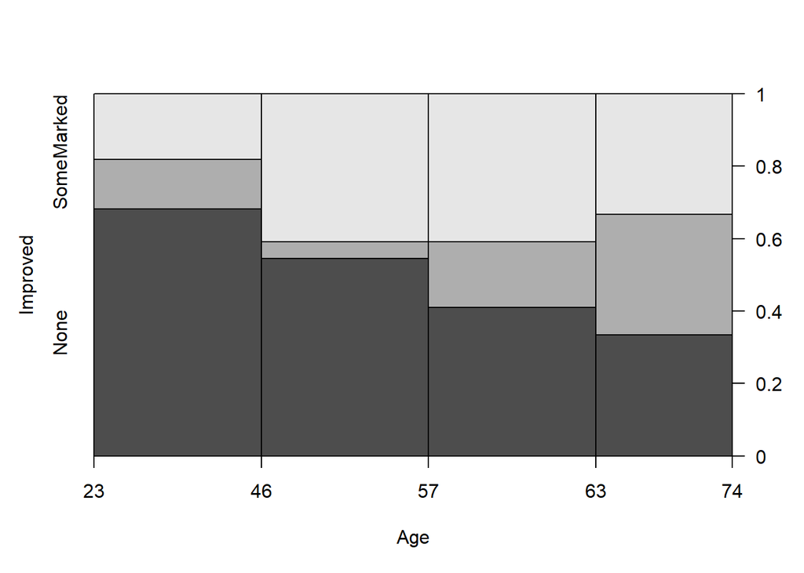

```
##          Improved
## Age       None Some Marked
##   [23,46]   15    3      4
##   (46,57]   12    1      9
##   (57,63]    9    4      9
##   (63,74]    6    6      6
```

```r
(spine(Improved ~ Age, data = Arthritis, breaks = quantile(Arthritis$Age)))
```

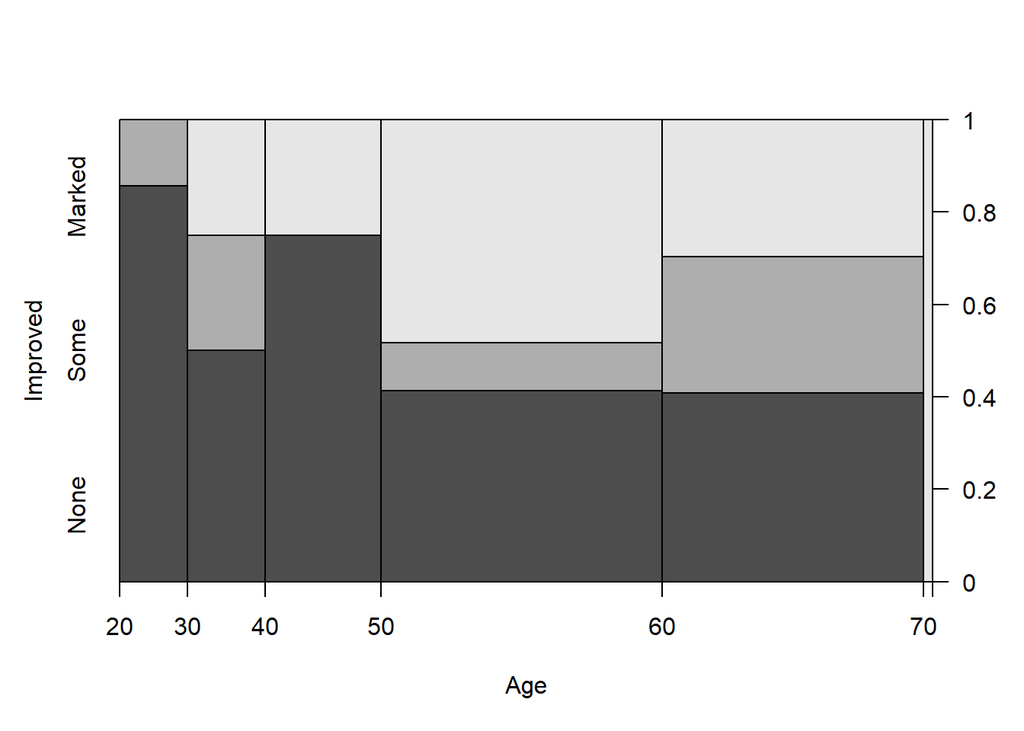

```
##          Improved
## Age       None Some Marked
##   [20,30]    6    1      0
##   (30,40]    4    2      2
##   (40,50]    9    0      3
##   (50,60]   12    3     14
##   (60,70]   11    8      8
##   (70,80]    0    0      1
```

```r
(spine(Improved ~ Age, data = Arthritis, breaks = "Scott"))
```

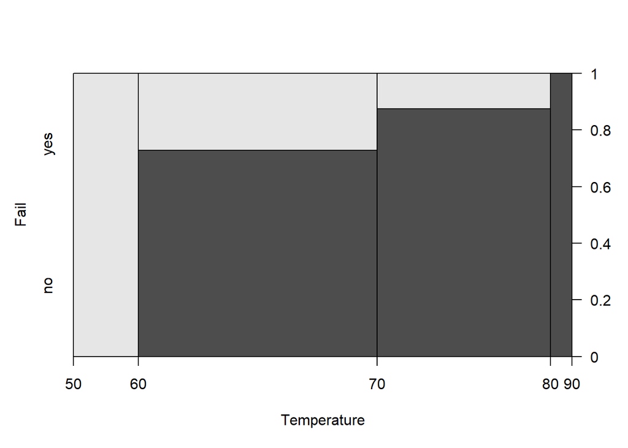

```
##            Fail
## Temperature no yes
##     [50,60]  0   3
##     (60,70]  8   3
##     (70,80]  7   1
##     (80,90]  1   0
```

```r
## Space shuttle data (dependence on a numerical variable)
data("SpaceShuttle")
(spine(Fail ~ Temperature, data = SpaceShuttle, breaks = 3))
```

#### Value

The table visualized is returned invisibly.

#### Details

spine creates either a spinogram or a spine plot. It can be called via spine(x, y) or spine(y ~ x) where y is interpreted to be the dependent variable (and has to be categorical) and x the explanatory variable. x can be either categorical (then a spine plot is created) or numerical (then a spinogram is plotted). Additionally, spine can also be called with only a single argument which then has to be a 2-way table, interpreted to correspond to table(x, y). Spine plots are a generalization of stacked bar plots where not the heights but the widths of the bars corresponds to the relative frequencies of x. The heights of the bars then correspond to the conditional relative frequencies of y in every x group. This is a special case of a mosaic plot with specific spacing and shading. Analogously, spinograms extend stacked histograms. As for the histogram, x is first discretized (using hist) and then for the discretized data a spine plot is created.

Author(s) Achim Zeileis Achim.Zeileis@R-project.org References Hummel, J. (1996), Linked bar charts: Analysing categorical data graphically. Computational Statistics, 11, 23-33. Hofmann, H., Theus, M. (2005), Interactive graphics for visualizing conditional distributions, Unpublished Manuscript. See Also cd_plot, mosaic, hist